# Depression and Its Social Determinants: A Multi-Model Analysis Using NHANES 2013–2018

Author

Mike Zhang

Published

June 9, 2026

# 1 Background

Depression is one of the most prevalent mental health conditions worldwide, affecting an estimated 280 million people globally. In the United States, it represents a leading cause of disability and is associated with substantial economic costs, reduced quality of life, and increased mortality risk.

While depression has well-established biological and psychological underpinnings, its distribution across populations is far from random. Social determinants, meaning the conditions in which people are born, grow, work, and age, play a meaningful role in shaping depression risk. Food insecurity, poverty, low educational attainment, and smoking have all been linked to higher depression prevalence in prior research, yet their relative importance and independence after mutual adjustment remains incompletely characterized.

This project uses three complementary analytical approaches, such as survey-weighted logistic regression, LASSO, and random forest, to examine which social determinants are most strongly and consistently associated with depression among US adults, using data from the National Health and Nutrition Examination Survey (NHANES) 2013–2018.

# 2 Methods

## 2.1 Data Source

Data were drawn from three cycles of the National Health and Nutrition Examination Survey (NHANES): 2013-2014, 2015–2016, and 2017–2018. NHANES is a nationally representative, cross-sectional survey conducted by the Centers for Disease Control and Prevention (CDC) that combines interviews, questionnaires, and physical examinations to assess the health and nutritional status of the US civilian non-institutionalized population. Survey weights were adjusted for the multi-cycle design by dividing the provided examination weights by three, and all descriptive analyses accounted for the complex survey design using pseudo-strata and pseudo-PSU variables.

## 2.2 Study Sample

The analytic sample was restricted to adults aged 18 and older. After excluding respondents with missing data on the outcome or key predictors, the final sample comprised 10350 participants.

## 2.3 Outcome

Depression was assessed using the Patient Health Questionnaire-9 (PHQ-9), a validated nine-item instrument asking respondents how often they experienced depressive symptoms over the past two weeks. Each item is scored 0–3, with a total score ranging from 0–27. Consistent with established clinical thresholds, respondents scoring 10 or above were classified as having moderate-to-severe depression.

## 2.4 Predictors

Social determinants examined included food security status (four levels: full, marginal, low, very low), family income-to-poverty ratio (log-transformed based on assumption checking), education (four levels: college graduate or above, some college, high school/GED, less than high school), smoking status (never, former, current), physical activity (vigorous, moderate, none), average alcohol consumption (drinks per day), and sleep duration (hours per night). Demographic covariates included age, sex, and race/ethnicity.

## 2.5 Missing Data

Missing data were handled via complete case analysis. A substantial proportion of missingness in alcohol consumption (ALQ130) was structural since respondents who reported never drinking or not drinking in the past year were skipped past the relevant question entirely. These were recoded as 0 drinks per day prior to analysis, recovering 1,272 additional observations. Remaining missingness was assessed for systematic patterns; lower-income and less-educated respondents were modestly overrepresented among those with missing data, suggesting findings should be interpreted with some caution. A table comparing the characteristics of complete and incomplete cases of key predictors is provided in the Appendix.

## 2.6 Statistical Analysis

Three complementary models were fitted:

Survey-weighted logistic regression was used as the primary inferential model, estimating odds ratios for each predictor while accounting for NHANES’s complex survey design via `svyglm()` with a quasibinomial family. This model provides interpretable effect estimates with appropriate confidence intervals and p-values.

LASSO (Least Absolute Shrinkage and Selection Operator) was fitted via the `tidymodels` framework to perform variable selection by identifying which social determinants survive penalization after controlling for all others. The penalty parameter λ was tuned via 10-fold cross-validation using AUC as the performance metric, with the final λ selected using the one standard error rule to favor parsimony.

Random forest was fitted using the `ranger` engine via `tidymodels`, with `mtry` and `min_n` tuned via random grid search and 10-fold cross-validation. Permutation importance was used to rank predictors by their contribution to model performance.

For the LASSO and random forest models, data were split into 80% training and 20% test sets prior to analysis. Model performance was evaluated on the held-out test set using AUC. All analyses were conducted in R version 4.6.

# 3 Results

## 3.1 Sample Characteristics

Table 1: Baseline characteristics of U.S. adults aged 18 and older by depression status, NHANES 2013–2018 (n = 10350). Values represent weighted population estimates presented as mean (SD) for continuous variables and n (%) for categorical variables

| **Characteristic** | **Overall** N = 164,280,171<sup>1</sup> | **No** N = 151,360,390<sup>1</sup> | **Yes** N = 12,919,781<sup>1</sup> | **p-value**<sup>2</sup> |
| --- | --- | --- | --- | --- |
| Age (years) | 46.9 (16.7) | 47.0 (16.8) | 45.8 (16.1) | 0.2 |
| Sex |  |  |  | <0.001 |
| Female | 50.1% | 49.0% | 64.1% |  |
| Male | 49.9% | 51.0% | 35.9% |  |
| Ethnicity |  |  |  | <0.001 |
| Non-Hispanic White | 67.7% | 67.9% | 65.5% |  |
| Mexican American | 8.1% | 8.3% | 6.3% |  |
| Non-Hispanic Asian | 4.4% | 4.6% | 2.1% |  |
| Non-Hispanic Black | 10.2% | 10.1% | 11.6% |  |
| Other Hispanic | 5.5% | 5.4% | 6.6% |  |
| Other Race - Including Multi-Racial | 4.0% | 3.7% | 7.9% |  |
| Family income-to-poverty ratio | 3.1 (1.6) | 3.2 (1.6) | 2.3 (1.6) | <0.001 |
| Alcohol consumption (dirnks/day) | 2.3 (2.2) | 2.3 (2.1) | 2.6 (2.7) | 0.070 |
| Sleep duration (hours) | 7.4 (1.4) | 7.4 (1.4) | 7.3 (1.9) | 0.054 |
| Patient Health Questionnaire (PHQ-9) score | 3.1 (4.0) | 2.2 (2.4) | 13.8 (3.7) | <0.001 |
| Education |  |  |  | <0.001 |
| College graduate+ | 33.8% | 35.1% | 18.1% |  |
| Some college | 32.8% | 32.6% | 36.2% |  |
| High school/GED | 23.1% | 22.7% | 26.8% |  |
| Less than high school | 10.3% | 9.6% | 18.9% |  |
| Food security |  |  |  | <0.001 |
| Full | 74.3% | 76.7% | 46.7% |  |
| Marginal | 9.7% | 9.3% | 14.4% |  |
| Low | 8.4% | 7.7% | 17.2% |  |
| Very low | 7.6% | 6.4% | 21.7% |  |
| Smoking status |  |  |  | <0.001 |
| Never | 54.6% | 56.1% | 36.7% |  |
| Former | 25.7% | 25.9% | 23.4% |  |
| Current | 19.7% | 17.9% | 39.9% |  |
| Physical activity |  |  |  | 0.4 |
| Vigorous | 25.2% | 25.0% | 27.3% |  |
| Moderate | 25.3% | 25.5% | 22.8% |  |
| None | 49.5% | 49.5% | 49.9% |  |

<sup>1</sup> Mean (SD); %  
<sup>2</sup> Design-based KruskalWallis test; Pearson’s X^2: Rao & Scott adjustment

## 3.2 Depression Prevalence by Subgroup

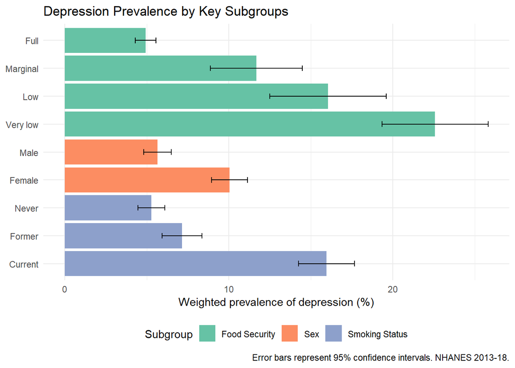

Figure 1: Weighted Depression Prevalence by key subgroups among U.S. adults aged 18 and older, NHANES 2013-18

Depression prevalence varied substantially across subgroups (Figure 1). The steepest gradient was observed for food security — prevalence ranged from 4.9% among those with full food security to 22.6% among those with very low food security, a more than fourfold difference. Current smokers had nearly three times the depression prevalence of never smokers (16.0% vs. 5.3%). Female adults had approximately twice the prevalence of male adults (10.1% vs. 5.7%).

## 3.3 Logistic Regression

Table 2: Survey-weighted logistic regression model estimates for depression among U.S. adults aged 18 and older, NHANES 2013–2018 (n = 10350)

| **Characteristic** | **OR** | **95% CI** | **p-value** |
| --- | --- | --- | --- |
| Age (years) | 1.00 | 1.00, 1.01 | 0.4 |
| Sex |  |  |  |
| Female | — | — |  |
| Male | 0.48 | 0.37, 0.62 | <0.001 |
| Race/Ethnicity |  |  |  |
| Non-Hispanic White | — | — |  |
| Mexican American | 0.51 | 0.35, 0.76 | 0.002 |
| Non-Hispanic Asian | 0.64 | 0.44, 0.95 | 0.028 |
| Non-Hispanic Black | 0.80 | 0.66, 0.96 | 0.021 |
| Other Hispanic | 0.92 | 0.64, 1.31 | 0.6 |
| Other Race - Including Multi-Racial | 1.62 | 1.09, 2.41 | 0.020 |
| Education |  |  |  |
| College graduate+ | — | — |  |
| Some college | 1.31 | 0.89, 1.95 | 0.2 |
| High school/GED | 1.24 | 0.84, 1.83 | 0.3 |
| Less than high school | 1.79 | 1.28, 2.51 | 0.002 |
| Income-to-poverty ratio (log) | 0.84 | 0.78, 0.91 | <0.001 |
| Food Security |  |  |  |
| Full | — | — |  |
| Marginal | 1.92 | 1.36, 2.72 | <0.001 |
| Low | 2.64 | 1.83, 3.82 | <0.001 |
| Very low | 3.48 | 2.68, 4.50 | <0.001 |
| Physical Activity |  |  |  |
| Vigorous | — | — |  |
| Moderate | 0.92 | 0.64, 1.33 | 0.6 |
| None | 1.13 | 0.85, 1.49 | 0.4 |
| Smoking Status |  |  |  |
| Never | — | — |  |
| Former | 1.36 | 1.02, 1.81 | 0.036 |
| Current | 2.11 | 1.56, 2.84 | <0.001 |
| Avg Drinks/Day | 1.03 | 0.99, 1.08 | 0.2 |
| Sleep Duration (hours) | 0.92 | 0.86, 1.00 | 0.038 |

Abbreviations: CI = Confidence Interval, OR = Odds Ratio

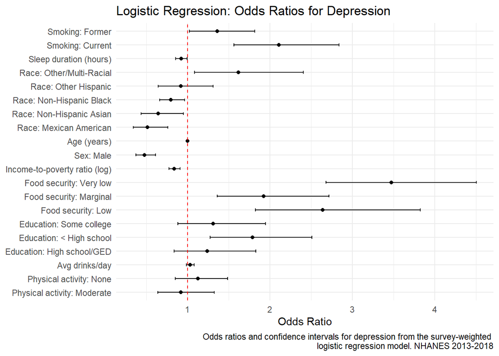

Figure 2

After adjusting for all covariates, food security remained the strongest predictor of depression (Table 2, Figure 2). Compared to full food security, very low food security was associated with 3.48 times the odds of depression (95% CI: 2.68–4.50), with a clear dose-response gradient through marginal (OR 1.92) and low (OR 2.64) food security levels. Current smoking was associated with more than twice the odds of depression compared to never smoking (OR 2.11, 95% CI: 1.56–2.84). Male sex was strongly protective (OR 0.48, 95% CI: 0.37–0.62). Each unit increase in log income-to-poverty ratio was associated with 16% lower odds of depression (OR 0.84, 95% CI: 0.78–0.91). Less than high school education was associated with 79% higher odds compared to college graduates (OR 1.79, 95% CI: 1.28–2.51), while higher education levels were not significantly different from the reference group after adjustment. Physical activity and alcohol consumption were not significantly associated with depression after adjustment.

Regarding race and ethnicity, relative to Non-Hispanic White adults, Mexican American (OR 0.51), Non-Hispanic Asian (OR 0.64), and Non-Hispanic Black (OR 0.80) adults had significantly lower odds of depression, while Other Race/Multi-Racial adults had higher odds (OR 1.62).

## 3.4 LASSO

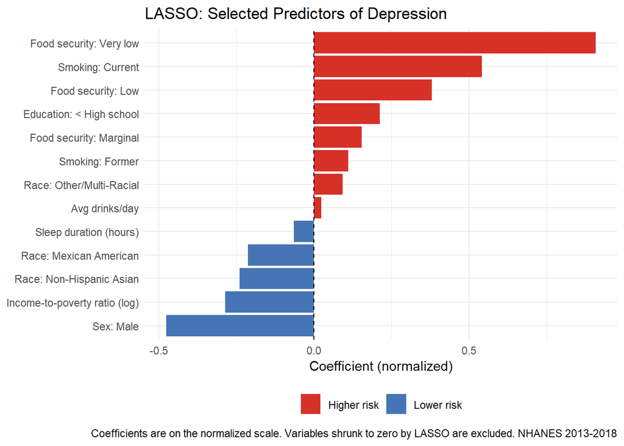

## 3.5 Random Forest

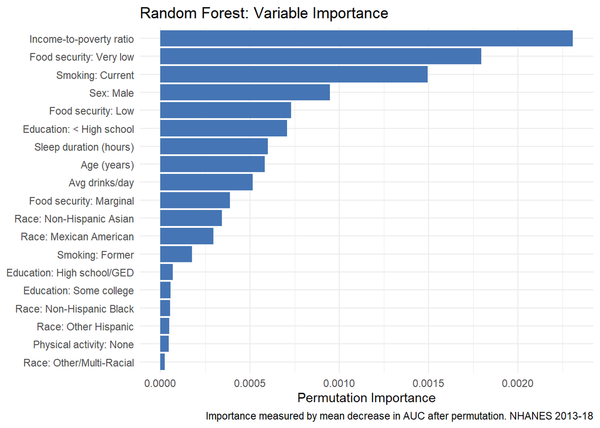

Figure 3: Variable importance plot of the random forest model of depression among U.S. adults aged 18 and older, NHANES 2013–2018 (n = 10350)

## 3.6 Model Comparison

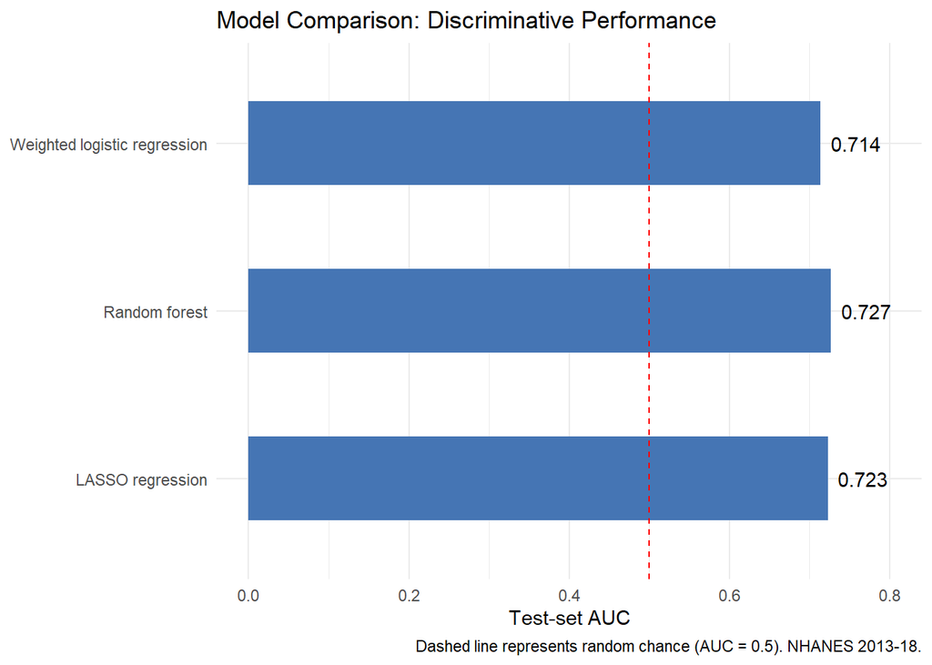

Figure 4: Area Under the Curve (AUC) comparison of the survey-weighted logistic regression, LASSO regression, and random forest models of depression among U.S. adults aged 18 and older, NHANES 2013–2018 (n = 10350)

# 4 Discussion

This study examined social determinants of depression among US adults using three complementary analytical approaches, survey-weighted logistic regression, LASSO, and random forest, applied to NHANES 2013–2018 data. Across all three models, food security, income, current smoking, and sex emerged as the most consistent and robust predictors of depression, while physical activity showed no meaningful association after adjustment.

## 4.1 Food Security and Income

The most striking finding was the strong, dose-response relationship between food insecurity and depression. Adults with very low food security had 3.48 times the odds of depression compared to those with full food security, a gradient that persisted across all three models. This is consistent with a growing body of literature linking food insecurity to poor mental health, though the direction of causality remains difficult to establish in cross-sectional data because depression may contribute to food insecurity as much as the reverse.

Income showed a non-linear protective relationship with depression, better captured by the random forest than the logistic regression. The log transformation of income in the logistic regression partially addressed this, but the random forest’s designation of income as the single most important predictor suggests the income-depression relationship is more complex than a log-linear model fully captures. Together, food security and income paint a consistent picture of economic hardship as a central driver of depression risk.

## 4.2 Smoking

Current smokers had more than twice the odds of depression compared to never smokers, and this association survived LASSO penalization. The relationship between smoking and depression is well-established but its directionality is debated — smoking may contribute to depression through neurobiological pathways, or depressed individuals may be more likely to smoke as a coping mechanism. The cross-sectional design of this study precludes causal inference on this question.

## 4.3 Sex

Male sex was strongly protective against depression (OR 0.48), consistent with the well-documented higher prevalence of depression among women. This difference likely reflects a combination of biological, psychological, and social factors, including differences in stress exposure, coping styles, and willingness to report depressive symptoms.

## 4.4 Race and Ethnicity

Relative to Non-Hispanic White adults, most racial and ethnic minority groups had lower odds of depression after adjustment, with the exception of Other Race/Multi-Racial adults. This pattern, sometimes called the “Hispanic paradox” or “immigrant health advantage,” has been documented in prior literature and may reflect cultural protective factors, differential symptom reporting, or survivor bias among immigrant populations. The higher odds among Other Race/Multi-Racial adults may reflect unique stressors associated with multiracial identity, though this group is heterogeneous and findings should be interpreted cautiously.

## 4.5 Physical Activity

Physical activity showed no significant association with depression in any of the three models, a somewhat surprising finding given the substantial literature linking exercise to mental health benefits. This null result may reflect limitations in how physical activity was measured in NHANES, where the binary vigorous/moderate/none classification may not capture the frequency, duration, or intensity of activity with sufficient granularity to detect an effect.

# 5 Limitations

Several limitations warrant mention. First, the cross-sectional design precludes causal inference — observed associations may reflect reverse causality or unmeasured confounding. Second, complete case analysis was used to handle missing data; lower-income and less-educated respondents were modestly overrepresented among those excluded, potentially leading to slight underestimation of depression prevalence and the strength of socioeconomic associations. Third, NHANES excludes institutionalized populations, who tend to have higher depression rates, which may further underestimate true prevalence. Fourth, the PHQ-9 is a screening tool rather than a diagnostic instrument, and the ≥10 threshold may misclassify some respondents. Fifth, the logistic regression assumes linearity in the log-odds for continuous predictors — while income was log-transformed to address a detected non-linearity, residual violations for other predictors cannot be ruled out.

# 6 Appendix

## 6.1 Missing Data Characterization

Table 3: Characteristics of missing data by variables with significant missiness, NHNES 2013-18

| **Characteristic** | **Any missing** N = 7,559<sup>1</sup> | **Complete** N = 10,402<sup>1</sup> | **p-value**<sup>2</sup> |
| --- | --- | --- | --- |
| Alcohol consumption (dirnks/day) | 2.3 (2.5) | 2.3 (2.3) | 0.003 |
| Depressed | 9.4% | 8.6% | 0.086 |
| Family income-to-poverty ratio | 2.1 (1.5) | 2.6 (1.6) | <0.001 |
| Education |  |  | <0.001 |
| College graduate+ | 20.5% | 27.3% |  |
| Some college | 27.3% | 33.0% |  |
| High school/GED | 22.2% | 23.0% |  |
| Less than high school | 30.0% | 16.7% |  |
| Food security |  |  | <0.001 |
| Full | 62.9% | 66.4% |  |
| Marginal | 14.2% | 12.4% |  |
| Low | 14.2% | 11.8% |  |
| Very low | 8.7% | 9.5% |  |

<sup>1</sup> Mean (SD); %  
<sup>2</sup> Wilcoxon rank sum test; Pearson’s Chi-squared test

Table 3 compares the characteristics of respondents with complete data versus those missing at least one key predictor.

## 6.2 B. Logistic Regression Assumption Checks

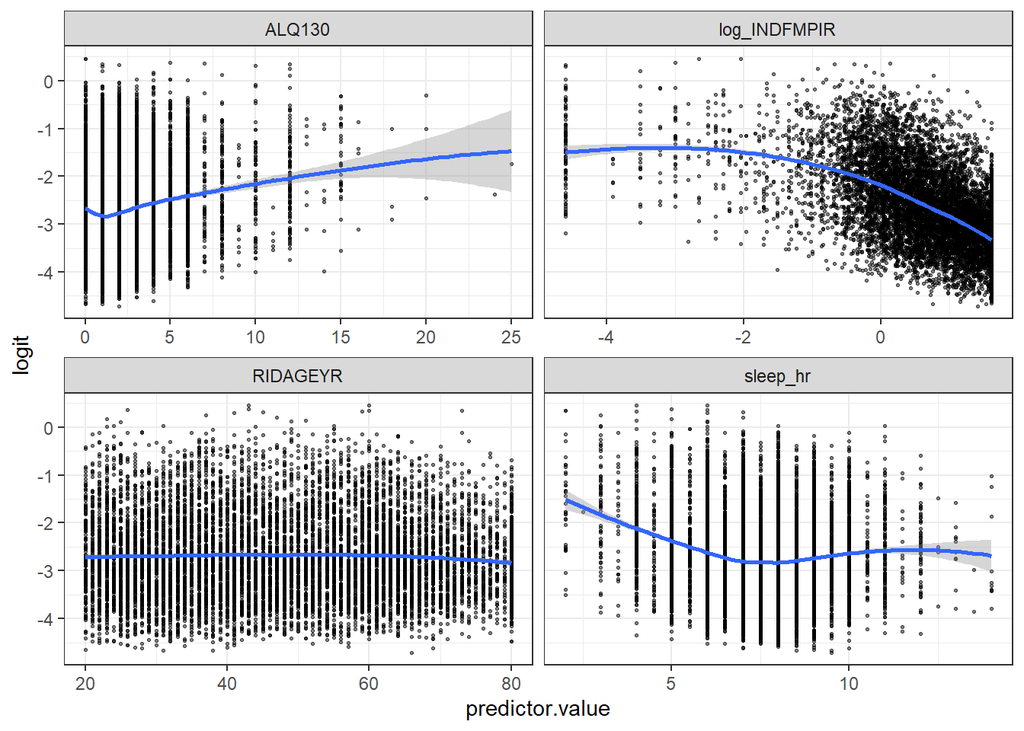

Figure 5: Survey-weighted logistic regression linearity assumption plot, NHANES 13-18

Figure 5 shows the relationship between each continuous predictor and the predicted log-odds of depression. Approximately linear relationships indicate the linearity assumption is satisfied. Income-to-poverty ratio was log-transformed based on visual inspection and model fit comparison (ΔAIC = 2.9).

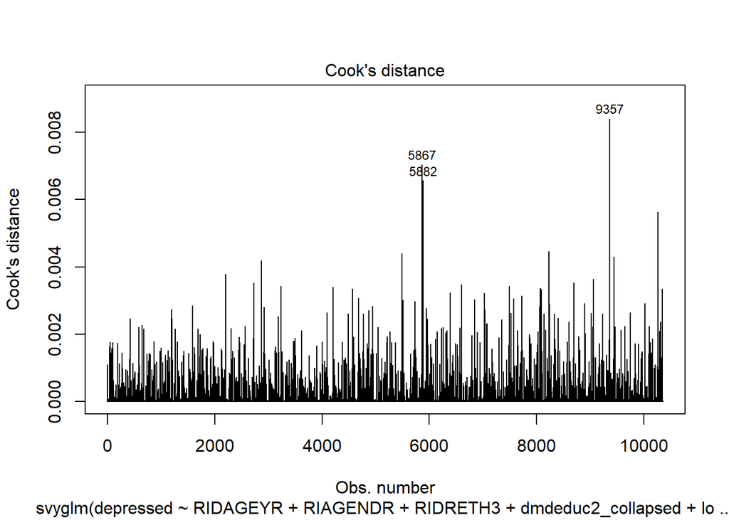

Figure 6: Cook’s distance plot, NHANES 2013-18

Figure 6 shows Cook’s distance for each observation. No observation exceeded a Cook’s distance of 0.01, indicating no severely influential observations.